# Enquête EuroBroadMap 2010

Attraction-répulsion des villes et pays

Auteur·rice

Claude Grasland

Date de publication

2025-08-26

Les questions relatives au choix de villes et de pays attractifs ou répulsifs ont fait l’objet d’un travail important de post-traitement afin d’éliminer les réponses erronées et coder les localisations des villes citées. Nous reproduisons ici la démarche qui a été suivie pour aboutir à un fichier d’analyse plus facile à manipuler statisttiquement et à cartographier.

## Forme du questionnaire

La partie B du questionnaire se composait en pratique de 4 blocs de questions inter-reliées entre lesquels nous avions introduit volontairement un *effet de halo*, c’es-à-dire assumé le fait que le choix des réponses à une question aurait une influence sur les autres. Il est de ca fait important de bien rappeler la mise en page visuelle du formulaire rempli sur papier par les étudiants :

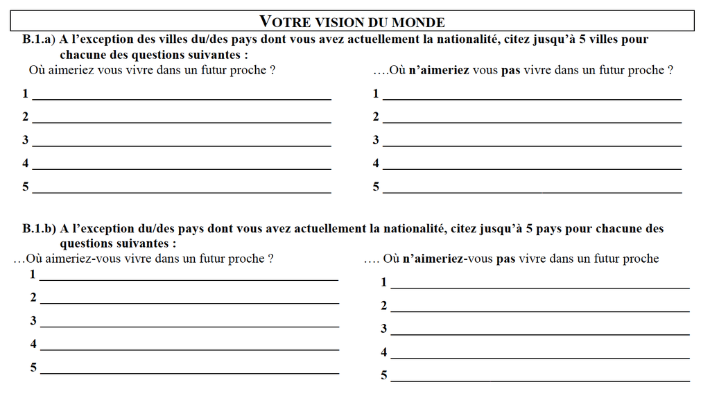

Question B du questionnaire EuroBroadMap

Plusieurs éléments sont à prendre en compte pour constituer un fichier restituant toute la richesse de ce bloc de question :

- **Exclusion du pays dont la personne a la nationalité** : Cette règle qui visait à forcer les étudiants à se projeter en dehors des limites de leur espace national n’a pas toujours été respectée. Il faut donc en principe mettre à part ou éliminer les réponses non conformes aux attentes. Mais en gardant en tête que les étudiants étrangers pouvaient déclarer dans leurs réponses les pays ou villes dans lesquelles ils ont été enquêtés. Ainsi, un étudiant camerounais qui aurait répondu à l’enquête pendant ses études à Paris pouvait déclarer la France ou Paris dans ses réponses.
- **Double présence des pays dans les réponses** : Les pays apparaissient évidemment directement dans les réponses aux questions où on leur demande ceux où ils voudraient vivre ou ne pas vivre. Mais ils apparaissent aussi indirectement dans le choix des villes où ils ont déclaré vouloir vivre ou ne pas vivre. Dans le premier cas, un pays est cité au plus une fois, soit en positif, soit en négatif. Dans le second cas, unpays peut apparaître plusieurs fois, aussi bien en positif qu’en négatif. Par exemple, un étudiant tunisien peut déclarer qu’il aimerait bien vivre à Marseille ou Montpellier mais pas à Paris ou Bordeaux.
- **Rang et nombre de réponses** : la mise en page suggère un ordre des réponses qu’il est intéressant de conserver. Il ne s’agit pas nécessairement d’un ordre de préférence ou de rejet. Mais plutôt un ordre chronologique qui révèle d’éventuelles associations d’idées suivies par la personne qui répond aux questions. Il s’agit en tous les cas d’une information intéressante à conserver. Quant au nombre de réponses, il n’est évidemment pas toujours égal au maximum proposé et doit être pris en considération dans les analyses.
- **Non respect des types de lieux attendus** : l’enquête portait sur les villes et les pays, mais certains étudiants n’ont pas respecté la consigne. Il y a tout d’abord eu des erreurs volontaires ou non de réponse par rapport à ces deux catégories. Ainsi, une ville peut apparaître dans les listes de pays ou l’inverse. Mais il peut aussi arriver, surtout dans le cas des pays, que les étudiants donnent en réponse des espaces infra-nationaux (e.g. Ecosse, Pays de Galles, …), des espaces suprantionaux (Eurpope, Afrique subsaharienne, …) , des espaces transnationaux (e.g. Kurdistan) voire des catégories non géographiques (pays riches, pays froids, …). Le codage des réponses doit permettre de conserver ces cas pourune analyse spéarée et, lorsque cela est possible, de les rattacher aux réponses attendues.
- **Ambiguïtés** : Il existe enfin des cas où la réponse n’a pau être identifiée ou est ambiguë.

Toutes ces questions soulèvent des problèmes complexes et imposent de faire des choix. La solution proposée dans le projet EuroBroadMap n’est donc pas la seule possible et il est important de garder la trace des choix effectués sous la forme d’un programme reproductible et modifiable.

## Extraction des pays

On commence par construire un nouveau tableau comportant les 10 réponses de chaque étudiant en format vertical. On ajoute une colonne “city” vide.

Le tableau passe alors de 9317 lignes (nombre d’étudiants) à 93170 puisqu’il y a dix réponses possibles. A ce stade, on conserve la totalité des réponses même lorsqu’elles sont vides. Prenons deux exemples d’étudiant ayant des réponses plus ou moins complètes

Réponse de deux étudiants sur les pays

| Code | state | city | name | type | rank | opi |
| --- | --- | --- | --- | --- | --- | --- |
| FRA-LEH-ART-001 | NA | NA | NA | STA | 1 | -1 |
| FRA-LEH-ART-001 | NA | NA | NA | STA | 2 | -1 |
| FRA-LEH-ART-001 | NA | NA | NA | STA | 3 | -1 |
| FRA-LEH-ART-001 | NA | NA | NA | STA | 4 | -1 |
| FRA-LEH-ART-001 | NA | NA | NA | STA | 5 | -1 |
| FRA-LEH-ART-001 | BEL | NA | Belgium | STA | 1 | 1 |
| FRA-LEH-ART-001 | CAN | NA | Canada | STA | 2 | 1 |
| FRA-LEH-ART-001 | NA | NA | NA | STA | 3 | 1 |
| FRA-LEH-ART-001 | NA | NA | NA | STA | 4 | 1 |
| FRA-LEH-ART-001 | NA | NA | NA | STA | 5 | 1 |
| FRA-LEH-ART-004 | ESP | NA | Spain | STA | 1 | -1 |
| FRA-LEH-ART-004 | BEL | NA | Belgium | STA | 2 | -1 |
| FRA-LEH-ART-004 | ITA | NA | Italy | STA | 3 | -1 |
| FRA-LEH-ART-004 | DEU | NA | Germany | STA | 4 | -1 |
| FRA-LEH-ART-004 | PRT | NA | Portugal | STA | 5 | -1 |
| FRA-LEH-ART-004 | JPN | NA | Japan | STA | 1 | 1 |
| FRA-LEH-ART-004 | X-NAM | NA | North America | STA | 2 | 1 |
| FRA-LEH-ART-004 | GBR | NA | United Kingdom | STA | 3 | 1 |
| FRA-LEH-ART-004 | NA | NA | NA | STA | 4 | 1 |
| FRA-LEH-ART-004 | NA | NA | NA | STA | 5 | 1 |

- **Commentaire** : Le premier étudiant a fourni deux réponses relatives aux pays où il aimerai vivre (Belgique et Canada) et aucune concernantles pays où il n’aimerai pas vivre. Le second étudiant a fourni 3 réponses concernant les pays où il aimerai vivre, dont une qui ne correspond pas à un pays (Amérique du Nord). Il a indiqué par ailleurs 5 pays où il n’aimerai pas vivre.

## Exraction des villes

On reccommence la même opération pour les dix questions sur les villes mais en remplissant cette fois-ci les deux colonnes relatives à la ville et au pays où elle se trouve.

Reprenons l’exemple des deux étudiants précédents pour voir comment leurs réponses sur les villes apparaissent dans le tableau :

Réponse de deux étudiants sur les villes

| Code | state | city | name | type | rank | opi |
| --- | --- | --- | --- | --- | --- | --- |
| FRA-LEH-ART-001 | NA | NA | NA | CIT | 1 | -1 |
| FRA-LEH-ART-001 | NA | NA | NA | CIT | 2 | -1 |
| FRA-LEH-ART-001 | NA | NA | NA | CIT | 3 | -1 |
| FRA-LEH-ART-001 | NA | NA | NA | CIT | 4 | -1 |
| FRA-LEH-ART-001 | NA | NA | NA | CIT | 5 | -1 |
| FRA-LEH-ART-001 | NA | NA | NA | CIT | 1 | 1 |
| FRA-LEH-ART-001 | NA | NA | NA | CIT | 2 | 1 |
| FRA-LEH-ART-001 | NA | NA | NA | CIT | 3 | 1 |
| FRA-LEH-ART-001 | NA | NA | NA | CIT | 4 | 1 |
| FRA-LEH-ART-001 | NA | NA | NA | CIT | 5 | 1 |
| FRA-LEH-ART-004 | ESP | MAD | Madrid | CIT | 1 | -1 |
| FRA-LEH-ART-004 | BEL | BRU1 | Bruxelles (= Brussel) | CIT | 2 | -1 |
| FRA-LEH-ART-004 | DEU | BER1 | Berlin | CIT | 3 | -1 |
| FRA-LEH-ART-004 | ITA | ROM | Roma | CIT | 4 | -1 |
| FRA-LEH-ART-004 | USA | MIA | Miami ** | CIT | 5 | -1 |
| FRA-LEH-ART-004 | USA | NYC | New York (NY) | CIT | 1 | 1 |
| FRA-LEH-ART-004 | JPN | TYO | Tokyo | CIT | 2 | 1 |
| FRA-LEH-ART-004 | GBR | LON | London | CIT | 3 | 1 |
| FRA-LEH-ART-004 | ISR | TLV | Tel Aviv-Yafo | CIT | 4 | 1 |
| FRA-LEH-ART-004 | NA | NA | NA | CIT | 5 | 1 |

- **Commentaire** : Le premier étudiant n’a fourni aucune réponse sur les villes qu’il considère comme attractives ou répulsives. Le second étduant a indiqué en revanche cinq villes répulsives et quatre villes attractives. Chacune des 9 villes citées a été reconnue et codée, ce qui a permis de remplir la colonne correspondant au pays dans lequel la ville se trouve. On a ici un bon exemple de cas où un pays peut-être cité à la fois positivement et négativement puisque l’étudiant declare qu’il aimerait bien vivre à New-York mais pas à Miami.

## Assemblage

On rassemble des deux tableaux en un seul et on leur ajoute des métadonnées pour faciliter la sélection ultérieure des étudiants en fonction de leur nombre de réponses aux quatre groupes de questions.

On peut désormais plus facilement extraire des échantillons répondant à certaines caractéristiques en terme de nombre de réponses. Voici un exemple de questionnaire complet où l’étudiant a fourni 20 réponses :

Cas d’un étudiant ayant répondu à toutes les questions

| Code | state | city | name | type | rank | opi | nbstalik | nbstaunl | nbcitlik | nbcitunl | nbsta | nbcit | nbrep |
| --- | --- | --- | --- | --- | --- | --- | --- | --- | --- | --- | --- | --- | --- |
| TUR-ERZ-ART-040 | IRN | THR | Tehran | CIT | 1 | -1 | 5 | 5 | 5 | 5 | 10 | 10 | 20 |
| TUR-ERZ-ART-040 | SYR | DAM | Damascus (= Damas) | CIT | 2 | -1 | 5 | 5 | 5 | 5 | 10 | 10 | 20 |
| TUR-ERZ-ART-040 | LBN | BEY | Beirut | CIT | 3 | -1 | 5 | 5 | 5 | 5 | 10 | 10 | 20 |
| TUR-ERZ-ART-040 | NA | XXXX | Palestine | CIT | 4 | -1 | 5 | 5 | 5 | 5 | 10 | 10 | 20 |
| TUR-ERZ-ART-040 | NA | XXXX | Africa | CIT | 5 | -1 | 5 | 5 | 5 | 5 | 10 | 10 | 20 |
| TUR-ERZ-ART-040 | ITA | VCE | Venice | CIT | 1 | 1 | 5 | 5 | 5 | 5 | 10 | 10 | 20 |
| TUR-ERZ-ART-040 | ITA | FLR | Florence | CIT | 2 | 1 | 5 | 5 | 5 | 5 | 10 | 10 | 20 |
| TUR-ERZ-ART-040 | DEU | HAM | Hamburg | CIT | 3 | 1 | 5 | 5 | 5 | 5 | 10 | 10 | 20 |
| TUR-ERZ-ART-040 | GRC | ATH | Athinai | CIT | 4 | 1 | 5 | 5 | 5 | 5 | 10 | 10 | 20 |
| TUR-ERZ-ART-040 | NA | XXXX | Scotland | CIT | 5 | 1 | 5 | 5 | 5 | 5 | 10 | 10 | 20 |
| TUR-ERZ-ART-040 | IRQ | NA | Iraq | STA | 1 | -1 | 5 | 5 | 5 | 5 | 10 | 10 | 20 |
| TUR-ERZ-ART-040 | IRN | NA | Iran Islamic Republic | STA | 2 | -1 | 5 | 5 | 5 | 5 | 10 | 10 | 20 |
| TUR-ERZ-ART-040 | PSE | NA | Occupied Palestinian Territory | STA | 3 | -1 | 5 | 5 | 5 | 5 | 10 | 10 | 20 |
| TUR-ERZ-ART-040 | ISR | NA | Israel | STA | 4 | -1 | 5 | 5 | 5 | 5 | 10 | 10 | 20 |
| TUR-ERZ-ART-040 | USA | NA | USA | STA | 5 | -1 | 5 | 5 | 5 | 5 | 10 | 10 | 20 |
| TUR-ERZ-ART-040 | GBR | NA | United Kingdom | STA | 1 | 1 | 5 | 5 | 5 | 5 | 10 | 10 | 20 |
| TUR-ERZ-ART-040 | FRA | NA | France | STA | 2 | 1 | 5 | 5 | 5 | 5 | 10 | 10 | 20 |
| TUR-ERZ-ART-040 | NLD | NA | Netherlands | STA | 3 | 1 | 5 | 5 | 5 | 5 | 10 | 10 | 20 |
| TUR-ERZ-ART-040 | DEU | NA | Germany | STA | 4 | 1 | 5 | 5 | 5 | 5 | 10 | 10 | 20 |
| TUR-ERZ-ART-040 | AUS | NA | Australia | STA | 5 | 1 | 5 | 5 | 5 | 5 | 10 | 10 | 20 |

- **Commentaire** : L’étudiant a bien fourni 20 réponses mais on peut voir que, dans le cas des villes, certaines réponses sont codées XXXX car elles ne corrrespondent pas à des villes mais à des espaces infranationaux (Palestine, Ecosse) ou supranationaux (Afrique). Nous ne modifions cependant pas le comptage puisque ce qui est mesuré ici est le nombre de réponses et non pas leur caractère conforme ou pas aux attentes.

On sauvegarde le tableau obtenu sous le nom *ebm2010_attrep* au format RDS et au format .csv

## Geocodage

Les ingénieurs du projet EuroBroadMap ont effectué un important travail de codage des villes et des pays cités, que nous allons récupérer mais aussi légèrement modifier ou compléter.

### Géocodage des pays ou assimilés

On commence par extraire tous les couples de noms de pays et de codes.

On charge ensuite un fonds de carte de référence comportant des codes iso3 et des clés d’agrégation vers des niveaux supérieurs et on effectue la jointure avec les code EuroBradMpa

Code ISO3 des pays du Monde et clés d’agrégation par régions ou continents

| iso3 | name | region | continent | n |
| --- | --- | --- | --- | --- |
| ABW | Aruba | Caribbean | Americas | 1 |
| AFG | Afghanistan | Southern Asia | Asia | 2070 |
| AGO | Angola | Middle Africa | Africa | 193 |
| AIA | Anguilla | Caribbean | Americas | 0 |
| ALB | Albania | Southern Europe | Europe | 87 |
| AND | Andorra | Southern Europe | Europe | 5 |

On vérifie le fonds de carte en représentant pour chaque pays le nombre de fois où il a été cité positivement ou négativement :

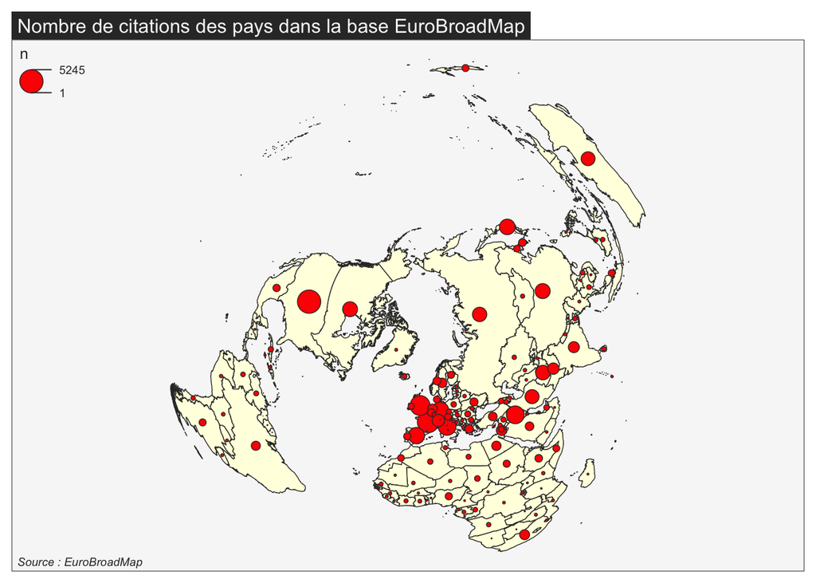

On sauvegarde le fichier cartographiques sous le nom *ebm_states* et on l’enregistre aux formats .RDS et .geojson.

On n’effectue pas ici de recodage des entités infra-nationales et on laisse à l’appréciation des chercheurs le choix - par exemple - de regrouper l’Ecosse ou le pays de Galles avec le Royaume-Uni. Les codes du type X-yyy permettent en effet de retrouver le pays auquel appartient une zone infranationale.